# GS

Muhammad Al Fatah

6/10/2021

**Catatan : Kodingan ini untuk memenuhi tugas simdat, kemungkinan banyak kesalahan. Mohon dimaklumi**

# Gibbs Sampler

## Contoh Gibbs Sampler (1)

Diketahui pengamatan $x_{1}, x_{2}, \dots, x_{n}$, mengikuti model eksponensial $p(x|a,b)= ab \ esp(-abx); x>0;a,b>0$ dengan prior:

$$\begin{align*}
p(a,b)= exp(-a -b); a,b>0
\end{align*}$$

Estimasi parameter $a$ dan $b$ Catatan: data dibangkitkan dengan perintah

```r
set.seed(123)
data <- rexp(100,4*5)
```

Jawab: Likelihood dari model eksponensial tersebut adalah

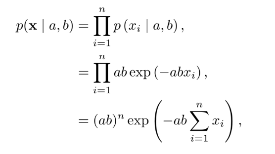

dan priornya adalah

$$\begin{align*}
p(a,b) & = exp(-a -b)\\
& = exp(-a)exp(-b)
\end{align*}$$

Posteriornya:

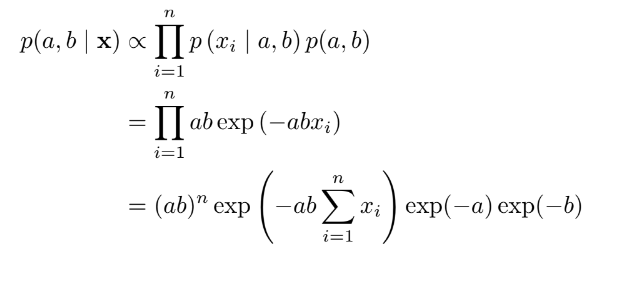

Full Conditional posterior distribution parameter $a$ adalah:

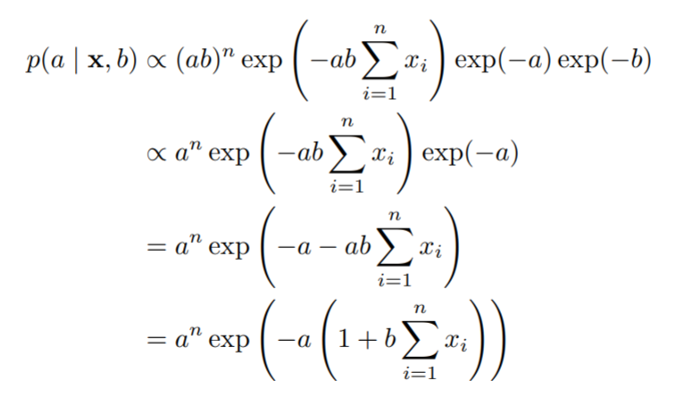

Ini berarti bahwa full conditional posterior distribution $a$ adalah $Gamma(n+1,(1+b\sum_{i=1}^n x_i))$

Untuk Full conditional posterior distribution parameter $b$ adalah:

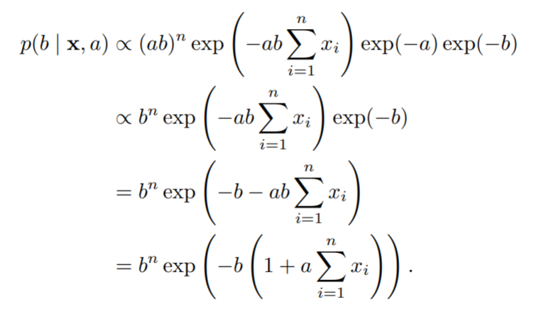

Ini berarti bahwa full conditional posterior distribution $b$ adalah $Gamma(n+1,(1+a\sum_{i=1}^n x_i))$

Rcode:

```r
sampleGibbs <- function(start.a, start.b, n.sims, data){
  # get sum, which is sufficient statistic
  sumx <- sum(data)
  # get n
  n <- nrow(data)
  # create empty matrix, allocate memory for efficiency
  res <- matrix(NA, nrow = n.sims, ncol = 2)
  res[1,] <- c(start.a,start.b)
  for (i in 2:n.sims){
    # sample the values
    res[i,1] <- rgamma(1, shape = n+1, rate = res[i-1,2]*sumx+1)
    res[i,2] <- rgamma(1, shape = n+1, rate = res[i,1]*sumx+1)
  }
  return(res)
}
```

### Menjalankan Gibbs Sampler

```r
library(coda)
n.sims <- 100000
# return the result (res)
data<-as.matrix(data)
theta <- sampleGibbs(4,4,n.sims,data) #start a dan b bebas
thetac2<-as.mcmc(theta)
summary(thetac2)
```

```
##
## Iterations = 1:1e+05
## Thinning interval = 1
## Number of chains = 1
## Sample size per chain = 1e+05
##
## 1. Empirical mean and standard deviation for each variable,
##    plus standard error of the mean:
##
##       Mean    SD Naive SE Time-series SE
## [1,] 4.520 1.541 0.004875        0.02193
## [2,] 4.545 1.572 0.004971        0.02257
##
## 2. Quantiles for each variable:
##
##       2.5%   25%   50%   75% 97.5%
## var1 2.193 3.408 4.286 5.375 8.166
## var2 2.233 3.419 4.296 5.395 8.324
```

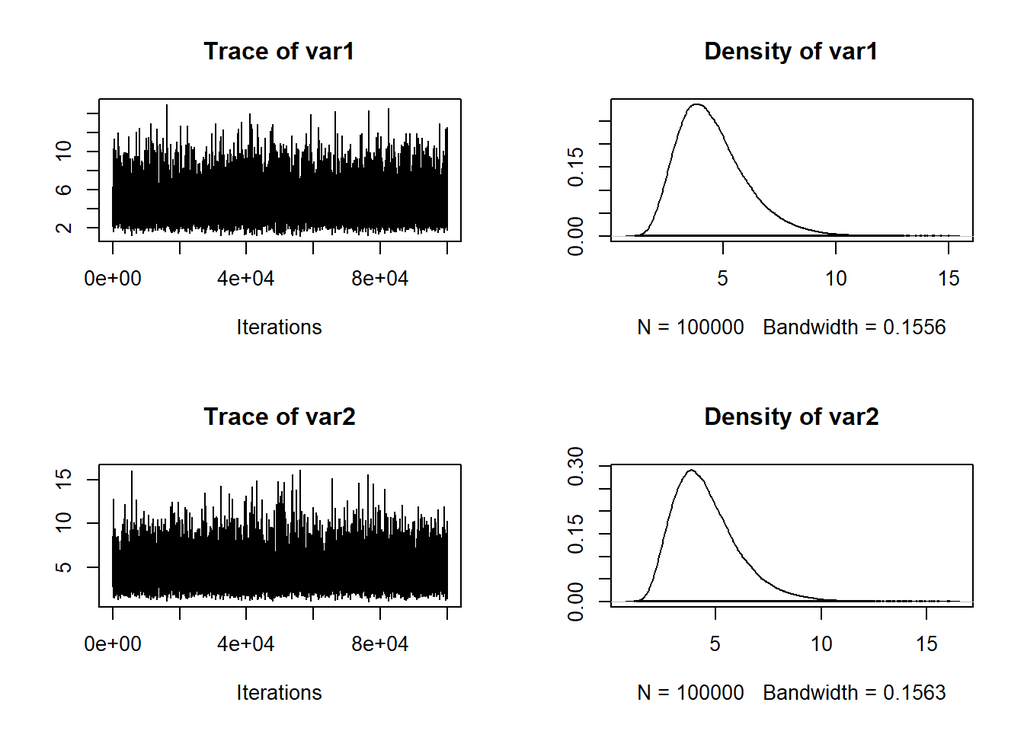

```r
plot(thetac2)
```

### Interpretasi

Salah satu cara melihat konvergen atau tidak bisa dilihat dari plotnya, jika garis densitynya mulus, dia bisa dibilang konvergen, jika masih bergerigi atau ada lonjakan, bisa ditambah iterasinya. Kemudian bisa juga dilihat dari tracenya, jika berbentuk seperti ulat gemuk, bisa dibilang konvergen.

### Uji Geweke

```r
geweke.diag(thetac2)
```

```
##
## Fraction in 1st window = 0.1
## Fraction in 2nd window = 0.5
##
##   var1   var2
##  1.321 -1.472
```

### Interpretasi Geweke

Jika kita menggunakan Uji Geweke, hasilnya jika dilihat dari Z-score (dengan tingkat signifikansi 5%), var1 dan var2 berada diantara -1.96 dan 1.96 artinya Gagal tolak H0, konvergen.

### Uji Raftery

```r
raftery.diag(thetac2)
```

```
##
## Quantile (q) = 0.025
## Accuracy (r) = +/- 0.005
## Probability (s) = 0.95
##
##  Burn-in  Total Lower bound  Dependence
##  (M)      (N)   (Nmin)       factor (I)
##  35       41013 3746         10.90
##  24       33012 3746          8.81
```

### Uji Heidel

```r
heidel.diag(thetac2)
```

```
##
##      Stationarity start     p-value
##      test         iteration
## var1 passed       1         0.793
## var2 passed       1         0.599
##
##      Halfwidth Mean Halfwidth
##      test
## var1 passed    4.52 0.0430
## var2 passed    4.55 0.0442
```

### Interpretasi Uji Heidel

Untuk uji Heidel menghasilkan passed, yang berarti dapat dikatakan stasioner.

### Uji Gelman

Uji Gelman dibutuhkan dua chain, maka dibuituhkan 1 chain lagi

```r
library(coda)
set.seed(12)
thetac3 <- as.mcmc(sampleGibbs(3, 3, 100000, data))
```

```r
thetac <- list(thetac2, thetac3)
gelman.diag(thetac)
```

```
## Potential scale reduction factors:
##
##      Point est. Upper C.I.
## [1,]          1          1
## [2,]          1          1
##
## Multivariate psrf
##
## 1
```

### Interpretasi Uji Gelman

Untuk uji Gelman hasilnya bisa dikatakan konvergen karena nilai Upper C.Inya = 1.

## Contoh Gibbs Sampler (2)

Diketahui
$$\begin{align*}
X_i & \sim {\sf Normal}(\theta,\sigma^2), i = 1,\dots,n \\
\theta & \sim {\sf Normal} (\theta_0,\tau^2), \\
\sigma^2 & \sim {\sf IG} (a,b) \\
\end{align*}$$

Catatan: IG adalah Invers Gamma. Jika $\sigma^2$ berdistribusi Invers Gamma, berarti $1/\sigma^2$ berdistribusi gamma. Estimasi parameter $\theta$ dan $\sigma$.

$a,b,\theta_0,\tau$ adalah hiperparameter yang nilainya ditentukan Kita pakai:

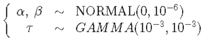

$\theta_0=0$ $\tau^2=1/10^{-6}=10^6$ $a,b=10^-3$

Jawab: Likelihood:
$$\begin{align*}
p(x|\theta,\sigma^2) & = \prod_{i = 1}^{n} \frac{1}{\sqrt{2\pi\sigma^2}} exp( \frac{-(x_i-\theta)^2}{2\sigma^2}) \\
& = (2\pi \sigma^2)^{-n/2} exp(-1/{2\sigma^2}\sum_{i=1}^{n} (x_i-\theta)^2)
\end{align*}$$

Prior:
$$\begin{align*}
p(\theta,\sigma^2)=\frac{1}{\sqrt{2\pi\tau^2}}exp(\frac{-(\theta-\theta_0)^2}{2\tau^2}) \ b^2/{\Gamma(a)}(\sigma^2)^{-a-1}exp(-b/\sigma^2)
\end{align*}$$

Full Conditional posterior distribution parameter $\theta$ adalah:

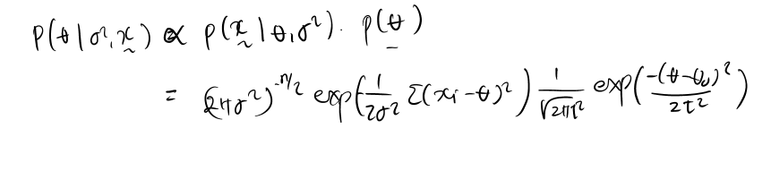

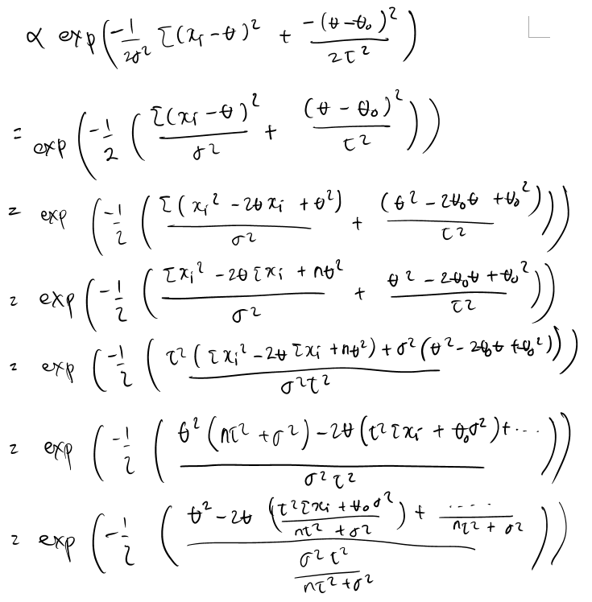

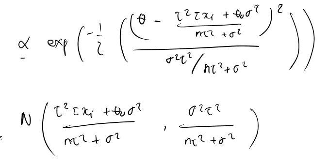

Ini berarti bahwa full conditional posterior distribution $\theta$ adalah $N(\frac{\tau^2\sum x_i +\theta_0\sigma^2}{n\tau^2+\sigma^2},\frac{\sigma^2\tau^2}{n\tau^2+\sigma^2})$

Full Conditional posterior distribution parameter $\sigma$ adalah:

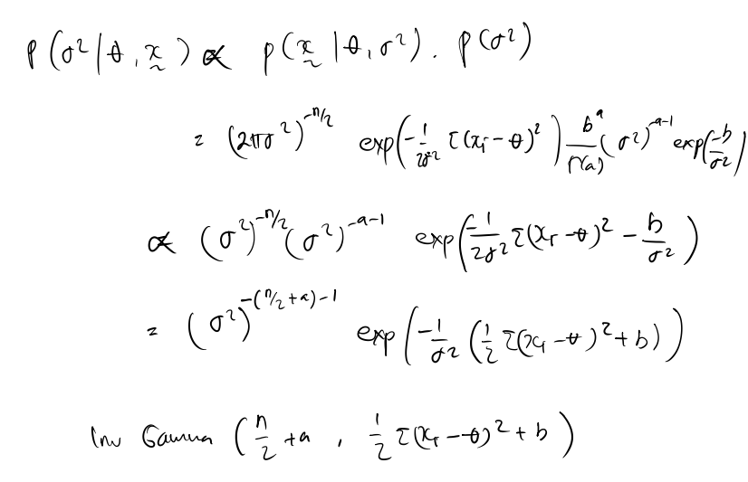

Ini berarti bahwa full conditional posterior distribution $\sigma$ adalah

$IG(\frac{n}{2}+a,\frac{1}{2} \sum(x_i-\theta)^2+b)$

```r
sampleGibbs <- function(start.a, start.b, n.sims, data){
  # get sum, which is sufficient statistic
  sumx <- sum(data)
  # get n
  n <- nrow(data)
  # create empty matrix, allocate memory for efficiency
  res <- matrix(NA, nrow = n.sims, ncol = 2)
  res[1,] <- c(start.a,start.b)
  for (i in 2:n.sims){
    # sample the values
    mu <- 10^(6)*sumx/(n*10^6 + res[i-1, 2]^2)
    sd <- sqrt(res[i-1, 2]^2*10^6/(n*10^6 + res[i-1, 2]^2))
    res[i,1] <- rnorm(1, mu, sd)
    a <- n/2 + 10^(-3)
    b <- sum((data - res[i, 1])^2)/2 + 10^(-3)
    res[i,2] <- sqrt(rinvgamma(1, a, b))
  }
  return(res)
}
```

```r
library(invgamma)
set.seed(123)
data <- rnorm(150, 7, 16)
n.sims <- 25000
# return the result (res)
data <- as.matrix(data)
thetag1 <- sampleGibbs(2, 10, n.sims, data)
thetag1 <-as.mcmc(thetag1)
summary(thetag1)
```

```
##
## Iterations = 1:25000
## Thinning interval = 1
## Number of chains = 1
## Sample size per chain = 25000
##
## 1. Empirical mean and standard deviation for each variable,
##    plus standard error of the mean:
##
##        Mean     SD Naive SE Time-series SE
## [1,]  6.603 1.2381 0.007830       0.007931
## [2,] 15.268 0.8913 0.005637       0.005637
##
## 2. Quantiles for each variable:
##
##        2.5%    25%    50%    75% 97.5%
## var1  4.179  5.767  6.596  7.432  9.05
## var2 13.642 14.645 15.226 15.843 17.13
```

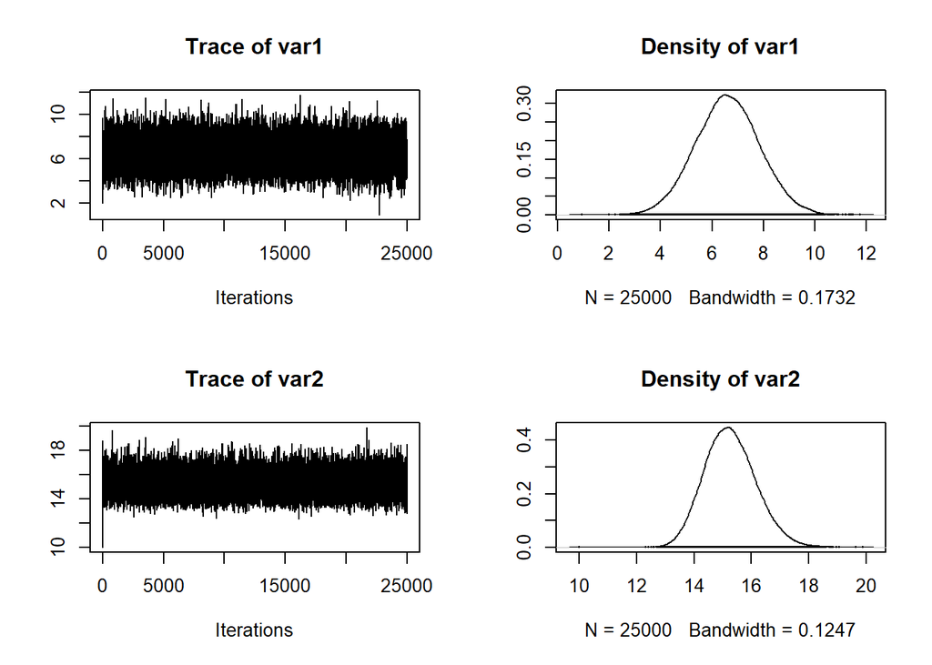

```r
plot(thetag1)
```

Dilihat dari plotnya sudah bisa dikatakan konvergen. Kemudian untuk rata-rata estimasi theta, yaitu 6.603 dan sigma 15.268. Aslinya theta sebesar 7 dan sigmanya sebesar 16.

Kemudian 95% nilai theta ada diantara 4.179 sampai 9.05, sedangkan sigma diantara 13.642 sampai 17.13.

### Uji Geweke

```r
geweke.diag(thetag1)
```

```
##
## Fraction in 1st window = 0.1
## Fraction in 2nd window = 0.5
##
##    var1    var2
## -0.4007  1.3130
```

Dari hasil diatas membuktikan bahwa kedua variabel ini konvergen karena nilainya diantara -1.96 sampai 1.96.

### Uji Raftery

```r
raftery.diag(thetag1)
```

```
##
## Quantile (q) = 0.025
## Accuracy (r) = +/- 0.005
## Probability (s) = 0.95
##
##  Burn-in  Total Lower bound  Dependence
##  (M)      (N)   (Nmin)       factor (I)
##  2        3723  3746         0.994
##  2        3847  3746         1.030
```

Dari hasil tersebut iterasi yang dilakukan sudah cukup dan Variabel bisa dikatakan independen karena mendekati nilai 1.

### Uji Heidel

```r
heidel.diag(thetag1)
```

```
##
##      Stationarity start     p-value
##      test         iteration
## var1 passed       1         0.502
## var2 passed       1         0.336
##
##      Halfwidth Mean Halfwidth
##      test
## var1 passed     6.6 0.0155
## var2 passed    15.3 0.0110
```

Dari uji Haidel ini semuanya sudah passed yang artinya sampelnya stasioner.

### Uji Gelman

```r
thetag2 <- as.mcmc(sampleGibbs(2.5, 11, 25000, data))

thetag <- list(thetag1, thetag2)

gelman.diag(thetag)
```

```
## Potential scale reduction factors:
##
##      Point est. Upper C.I.
## [1,]          1          1
## [2,]          1          1
##
## Multivariate psrf
##
## 1
```

Dari hasil uji Gelman nilai upper C.I-nya adalah 1 yang berarti konvergen.

## Contoh Gibbs Sampler (3)

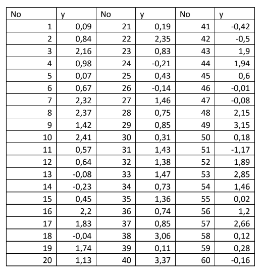

Misalkan data di atas berdistribusi Normal, $y \sim N(\mu,\sigma^2)$. $\mu$ dan $\sigma^2$ diestimasi menggunakan metode Bayesian dengan ditentukan priornya adalah $\mu \sim Normal(m,s^2)$ dan $\sigma^{-2} = \tau \sim Gamma(a,b)$. Estimasi $\mu$ dan $\sigma^2$

Jawab:

Likelihood:

$$\begin{align*}
p(\mathbf{y}|\mu,\sigma^2) & = \prod_{i=1}^n p(y_i|\mu,\sigma^2) \\
& = (2\mu\sigma^2)^{-\frac{n}{2}}exp(-\frac{1}{2\sigma^2}\sum_{i=1}^n (y_i-\mu)^2)
\end{align*}$$

$\sigma^{-2} = \tau \sim Gamma(a,b)$, prior dari modelnya adalah:

$p(\mu,\sigma^2)=\frac{1}{\sqrt{2\pi s^2}} exp(-\frac{(\mu-m)^2}{2s^2})\frac{b^a}{\Gamma(a)}(\sigma^2)^{-a-1}exp(-\frac{b}{\sigma^2})$

Prior yang diberikan tidak informatif, maka kita pakai:

$\mu \sim N(0,10^6)$ $\sigma^2\sim Inv Gamma(10^{-3},10^{-3})$

Posterior dari model tersebut:

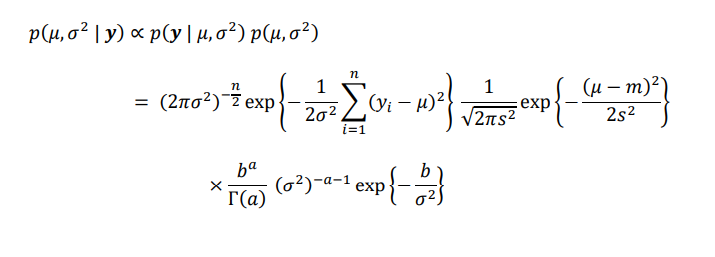

Full conditional posterior untuk $\mu$:

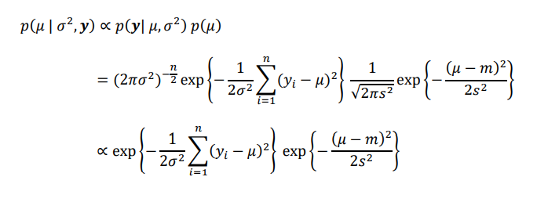

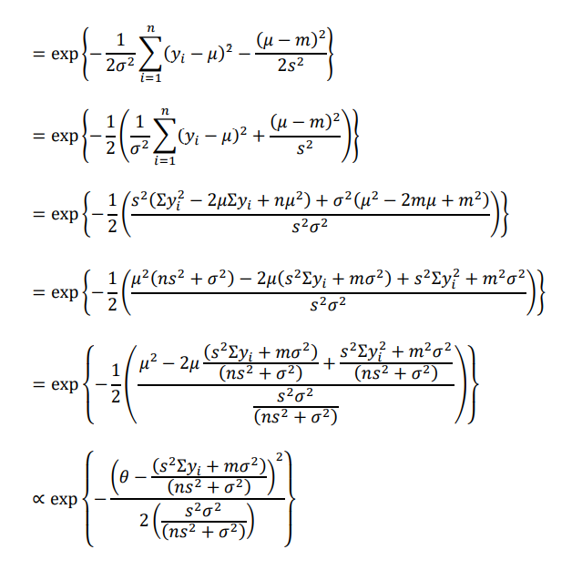

Full conditionalnya: $\mu | \sigma^2,\mathbf{y}\sim N(\frac{s^2\sum y_i+m\sigma^2}{ns^2+\sigma^2},\frac{s^2\sigma^2}{ns^2+\sigma^2})$

Full conditional posterior untuk $\sigma^2$:

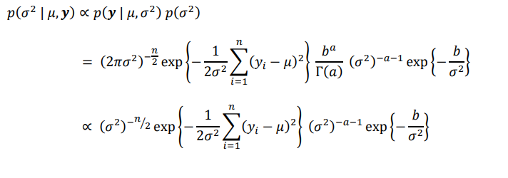

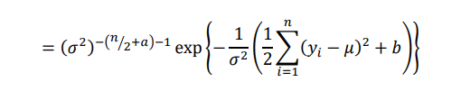

Full conitionalnya: $\sigma^2 | \mu, \mathbf y \sim Inv Gamma(\frac{n}{2}+a,\frac{1}{2}\sum_{i=1}^n (y_i-\mu)^2+b)$

```r
sampleGibbs <- function(mu, sig2, n.sims, data){
  # get sum, which is sufficient statistic
  sumx <- sum(data)
  # get n
  n <- nrow(data)
  # create empty matrix, allocate memory for efficiency
  res <- matrix(NA, nrow = n.sims, ncol = 2, dimnames = list(c(),c("mu", "sig2")))
  res[1,] <- c(mu,sig2)
  for (i in 2:n.sims){
    # sample the values
    mu <- 10^(6)*sumx/(n*10^6 + res[i-1, 2]^2)
    sd <- sqrt(res[i-1, 2]^2*10^6/(n*10^6 + res[i-1, 2]^2))
    res[i,1] <- rnorm(1, mu, sd)
    a <- n/2 + 10^(-3)
    b <- sum((data - res[i, 1])^2)/2 + 10^(-3)
    res[i,2] <- sqrt(rinvgamma(1, a, b))
  }
  return(res)
}
```

```r
data<-read.csv2("data/quiz.csv")
data<-data[,2]
n.sims <- 25000
# return the result (res)
data <- as.matrix(data)
thetag1 <- sampleGibbs(0, 1, n.sims, data)
thetag1 <-as.mcmc(thetag1)
summary(thetag1)
```

```
##
## Iterations = 1:25000
## Thinning interval = 1
## Number of chains = 1
## Sample size per chain = 25000
##
## 1. Empirical mean and standard deviation for each variable,
##    plus standard error of the mean:
##
##       Mean      SD  Naive SE Time-series SE
## mu   1.015 0.13756 0.0008700      0.0008700
## sig2 1.058 0.09959 0.0006299      0.0006364
##
## 2. Quantiles for each variable:
##
##        2.5%    25%   50%   75% 97.5%
## mu   0.7460 0.9219 1.015 1.107 1.283
## sig2 0.8855 0.9877 1.050 1.119 1.277
```

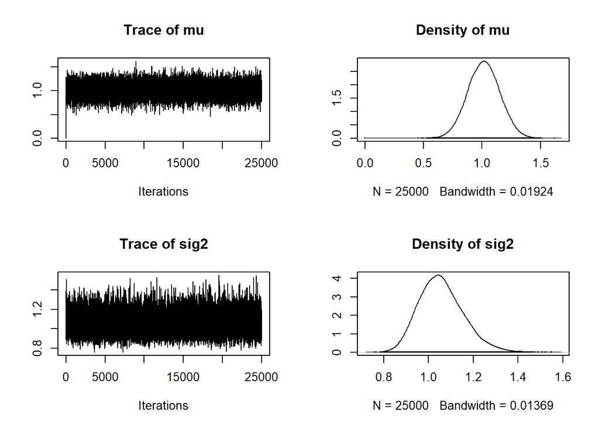

```r
plot(thetag1)
```

### Uji Geweke

```r
geweke.diag(thetag1)
```

```
##
## Fraction in 1st window = 0.1
## Fraction in 2nd window = 0.5
##
##       mu     sig2
## -0.08948 -1.94633
```

Dari hasil diatas membuktikan bahwa kedua variabel ini konvergen karena nilainya diantara -1.96 sampai 1.96.

### Uji Raftery

```r
raftery.diag(thetag1)
```

```
##
## Quantile (q) = 0.025
## Accuracy (r) = +/- 0.005
## Probability (s) = 0.95
##
##       Burn-in  Total Lower bound  Dependence
##       (M)      (N)   (Nmin)       factor (I)
##  mu   2        3759  3746         1.00
##  sig2 2        3790  3746         1.01
```

Dari hasil tersebut iterasi yang dilakukan sudah cukup dan Variabel bisa dikatakan independen karena mendekati nilai 1.

### Uji Heidel

```r
heidel.diag(thetag1)
```

```
##
##      Stationarity start     p-value
##      test         iteration
## mu   passed       1         0.156
## sig2 passed       1         0.179
##
##      Halfwidth Mean Halfwidth
##      test
## mu   passed    1.01 0.00171
## sig2 passed    1.06 0.00125
```

Dari uji Haidel ini semuanya sudah passed yang artinya sampelnya stasioner.